# **Project Name** - Play Store App review analysis EDA

##### **Contribution** - Individual

##### **Team Member 1 -** Ankit Salve

##### **Team Member 2 -**

##### **Team Member 3 -**

##### **Team Member 4 -**

# **Project Summary -**

Project Summary: Exploratory Data Analysis on Playstore Data

Exploratory Data Analysis (EDA) on the Playstore dataset, which provides details on the apps available on the Google Playstore, is the goal of this research. The Playstore dataset contains information about the app's name, rating, amount of downloads, category, and price, among other things.

13 features and nearly 10,000 observations are included. The dataset is in CSV format, and before analysis it needs to be cleaned up and preprocessed. Data cleaning, data visualisation, and statistical analysis are just a few of the tasks that the EDA process will involve.

The project's main objectives are as follows:

**Data cleaning**: The dataset has to be fixed because it has multiple duplicates and missing values. To make sure that the study is based on high-quality data, the data cleaning procedure will involve locating and eliminating these irregularities.

**Data Visualization**: As part of the EDA process, visuals will be made to investigate the distribution and relationships of the data. This will make it easier to see any anomalies or outliers in the data as well as patterns and trends.

A **statistical analysis** of the data will be performed as part of the project to find correlations between variables and determine the importance of these connections.

**Insights and Recommendations**: The project will offer insights and suggestions on the characteristics and attributes of the Playstore applications based on the outcomes of the EDA. App developers and marketers can use these insights to enhance the functionality and user experience of their applications.

The project's intended results include identifying the most well-liked programme categories, comprehending the effect of pricing on download rates, and pinpointing the elements that lead to higher user ratings.

Ultimately, the project will offer insightful information into the Playstore data, empowering marketers and developers to make data-driven choices and enhance the functionality and quality of their products.

# **GitHub Link -**

https://github.com/Salveankit/EDA_Play-Store-App-review-analysis.git

# **Problem Statement**

1. Distribution of Free and Paid App
2. Distribution of Content Rating on Play Store.
3. What is the distribution of Price and Rating in Play Store?
4. What is the most popular app size range?
5. What is the correlation between app size and rating?
6. What is the most popular app category in terms of the counts?
7. What is the most popular app category in terms of the number of downloads?
8. Which app category have highest average price of installation?
9. What is the top 10 most downloaded apps from GAMES category?
10. What is the average app size across different categories??
11. Average rating and total reviews by Category.
12. Which is the highest earning App category on Play Store?
13. What is Overall Revenue trend over past few years for highest earning app category?
14. Top 10 Highest earning Apps
15. Best performing App from each Category
16. Average Number of Apps installed every year.
17. Top apps with the highest number of POSITIVE reviews and categories.
18. Top apps with the highest number of NEGATIVE reviews and categories.
19. Sentiment Distribution
20. Sentiment Subjectivity Distribution with Histogram
21. Pair Plot
22. Correlation Heatmap

#### **Define Your Business Objective?**

**Objective :**

Help companies understand to user behavior, improve user experience, identify trends and opportunities, analyze competitive analysis, and gain insights that can help companies improve their apps, increase user engagement and retention, and drive revenue growth.

# **General Guidelines** : -

1. Well-structured, formatted, and commented code is required.
2. Exception Handling, Production Grade Code & Deployment Ready Code will be a plus. Those students will be awarded some additional credits.

   The additional credits will have advantages over other students during Star Student selection.

   ```
       [ Note: - Deployment Ready Code is defined as, the whole .ipynb notebook should be executable in one go
                 without a single error logged. ]
   ```

3. Each and every logic should have proper comments.
4. You may add as many number of charts you want. Make Sure for each and every chart the following format should be answered.

```
# Chart visualization code
```

- Why did you pick the specific chart?
- What is/are the insight(s) found from the chart?
- Will the gained insights help creating a positive business impact? Are there any insights that lead to negative growth? Justify with specific reason.
1. You have to create at least 20 logical & meaningful charts having important insights.

[ Hints : - Do the Vizualization in a structured way while following "UBM" Rule.

U - Univariate Analysis,

B - Bivariate Analysis (Numerical - Categorical, Numerical - Numerical, Categorical - Categorical)

M - Multivariate Analysis ]

# *Let's Begin !*

## *1. Know Your Data*

### Import Libraries

```python
# Import Libraries
import numpy as np
import pandas as pd
from numpy import math


#  Import Visualization libraries
import seaborn as sns
import matplotlib.pyplot as plt
import plotly.express as px
import plotly.graph_objects as go
from matplotlib import rcParams

# Importing datetime modules
from datetime import datetime
from datetime import date

import warnings
warnings.filterwarnings('ignore')
```

### Dataset Loading

```python
# Load Dataset
# Importing Playstore Data
url1='https://drive.google.com/file/d/1tyv7zjBpLN_Jax6CC7MDDE4nB5Qtn3pX/view?usp=share_link'
url1='https://drive.google.com/uc?id=' + url1.split('/')[-2]
df1 = pd.read_csv(url1)

# Importing User reviews Data
url2='https://drive.google.com/file/d/1WNNWi75EyGawpsfwmmJJDFinhWdOqdt8/view?usp=share_link'
url2='https://drive.google.com/uc?id=' + url2.split('/')[-2]
df2 = pd.read_csv(url2)
```

### Dataset First View

```python
# Dataset First Look
#Playstore Data and user reviews first few entries
df1.head()
```

|  | App | Category | Rating | Reviews | Size | Installs | Type | Price | Content Rating | Genres | Last Updated | Current Ver | Android Ver |
| --- | --- | --- | --- | --- | --- | --- | --- | --- | --- | --- | --- | --- | --- |
| 0 | Photo Editor & Candy Camera & Grid & ScrapBook | ART_AND_DESIGN | 4.1 | 159 | 19M | 10,000+ | Free | 0 | Everyone | Art & Design | January 7, 2018 | 1.0.0 | 4.0.3 and up |
| 1 | Coloring book moana | ART_AND_DESIGN | 3.9 | 967 | 14M | 500,000+ | Free | 0 | Everyone | Art & Design;Pretend Play | January 15, 2018 | 2.0.0 | 4.0.3 and up |
| 2 | U Launcher Lite – FREE Live Cool Themes, Hide ... | ART_AND_DESIGN | 4.7 | 87510 | 8.7M | 5,000,000+ | Free | 0 | Everyone | Art & Design | August 1, 2018 | 1.2.4 | 4.0.3 and up |
| 3 | Sketch - Draw & Paint | ART_AND_DESIGN | 4.5 | 215644 | 25M | 50,000,000+ | Free | 0 | Teen | Art & Design | June 8, 2018 | Varies with device | 4.2 and up |
| 4 | Pixel Draw - Number Art Coloring Book | ART_AND_DESIGN | 4.3 | 967 | 2.8M | 100,000+ | Free | 0 | Everyone | Art & Design;Creativity | June 20, 2018 | 1.1 | 4.4 and up |

```python
df2.head()
```

|  | App | Translated_Review | Sentiment | Sentiment_Polarity | Sentiment_Subjectivity |
| --- | --- | --- | --- | --- | --- |
| 0 | 10 Best Foods for You | I like eat delicious food. That's I'm cooking ... | Positive | 1.00 | 0.533333 |
| 1 | 10 Best Foods for You | This help eating healthy exercise regular basis | Positive | 0.25 | 0.288462 |
| 2 | 10 Best Foods for You | NaN | NaN | NaN | NaN |
| 3 | 10 Best Foods for You | Works great especially going grocery store | Positive | 0.40 | 0.875000 |
| 4 | 10 Best Foods for You | Best idea us | Positive | 1.00 | 0.300000 |

### Dataset Rows & Columns count

```python
# Dataset Rows & Columns count
print(f'the rows and columns in playstore dataset is {df1.shape}')
```

```
the rows and columns in playstore dataset is (10841, 13)
```

```python
print(f'the rows and columns in user dataset is {df2.shape}')
```

```
the rows and columns in user dataset is (64295, 5)
```

### Dataset Information

```python
# Dataset Info
#playstore Dataset
df1.info()
```

```
<class 'pandas.core.frame.DataFrame'>
RangeIndex: 10841 entries, 0 to 10840
Data columns (total 13 columns):
 #   Column          Non-Null Count  Dtype
---  ------          --------------  -----
 0   App             10841 non-null  object
 1   Category        10841 non-null  object
 2   Rating          9367 non-null   float64
 3   Reviews         10841 non-null  object
 4   Size            10841 non-null  object
 5   Installs        10841 non-null  object
 6   Type            10840 non-null  object
 7   Price           10841 non-null  object
 8   Content Rating  10840 non-null  object
 9   Genres          10841 non-null  object
 10  Last Updated    10841 non-null  object
 11  Current Ver     10833 non-null  object
 12  Android Ver     10838 non-null  object
dtypes: float64(1), object(12)
memory usage: 1.1+ MB
```

```python
# User dataset info
df2.info()
```

```
<class 'pandas.core.frame.DataFrame'>
RangeIndex: 64295 entries, 0 to 64294
Data columns (total 5 columns):
 #   Column                  Non-Null Count  Dtype
---  ------                  --------------  -----
 0   App                     64295 non-null  object
 1   Translated_Review       37427 non-null  object
 2   Sentiment               37432 non-null  object
 3   Sentiment_Polarity      37432 non-null  float64
 4   Sentiment_Subjectivity  37432 non-null  float64
dtypes: float64(2), object(3)
memory usage: 2.5+ MB
```

#### Duplicate Values

```python
# Dataset Duplicate Value Count
len(df1[df1.duplicated()])
```

```
483
```

```python
len(df2[df2.duplicated()])
```

```
33616
```

#### Missing Values/Null Values

```python
# Missing Values/Null Values Count
# Null values from playstore dataset
print(df1.isnull().sum())
```

```
App                  0
Category             0
Rating            1474
Reviews              0
Size                 0
Installs             0
Type                 1
Price                0
Content Rating       1
Genres               0
Last Updated         0
Current Ver          8
Android Ver          3
dtype: int64
```

```python
# Null values from user dataset
print(df2.isnull().sum())
```

```
App                           0
Translated_Review         26868
Sentiment                 26863
Sentiment_Polarity        26863
Sentiment_Subjectivity    26863
dtype: int64
```

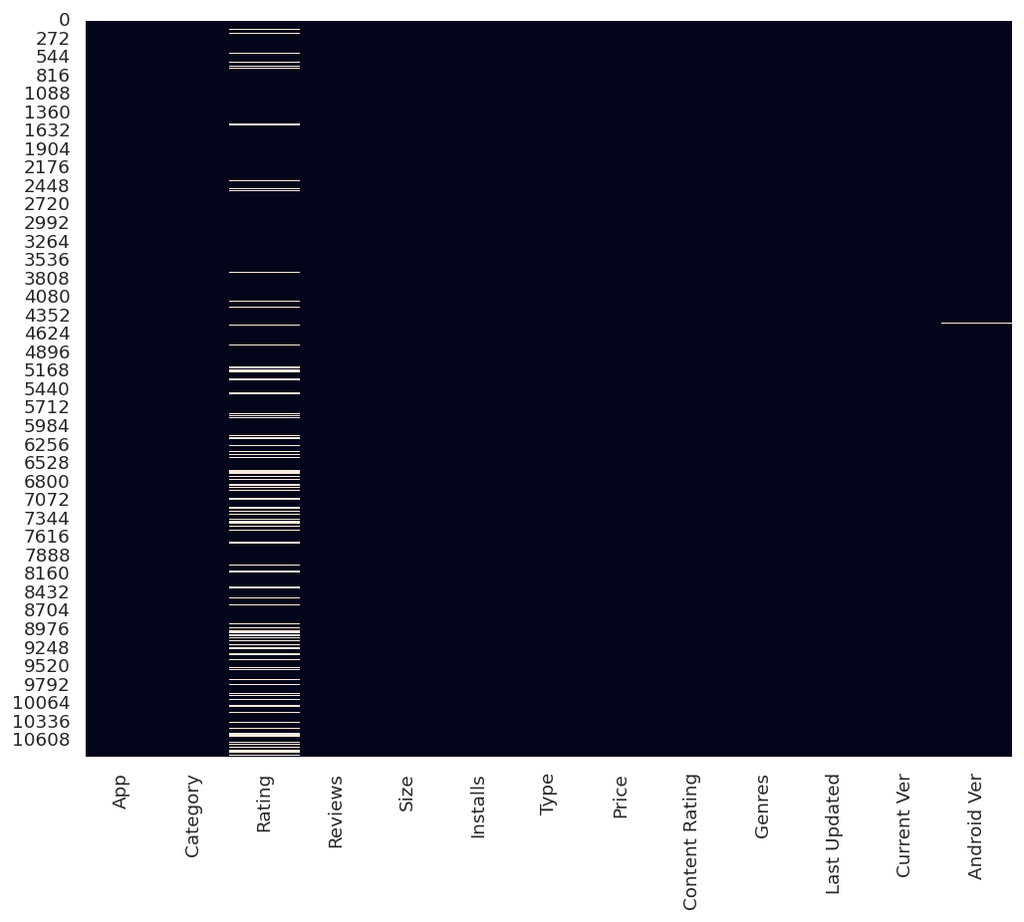

```python
# Visualizing the missing values
# to visualize missing data we can use the heatmap method.

# Let's set the theme of plots.
sns.set_theme()
sns.set(rc={"figure.dpi":120, "figure.figsize":(10,8)})
sns.heatmap(df1.isnull(), cbar=False)
```

## *2. Understanding Your Variables*

```python
# Dataset Columns
df1.columns
```

```
Index(['App', 'Category', 'Rating', 'Reviews', 'Size', 'Installs', 'Type',
       'Price', 'Content Rating', 'Genres', 'Last Updated', 'Current Ver',
       'Android Ver'],
      dtype='object')
```

```python
df2.columns
```

```
Index(['App', 'Translated_Review', 'Sentiment', 'Sentiment_Polarity',
       'Sentiment_Subjectivity'],
      dtype='object')
```

```python
# Dataset Describe returns descriptive statistics of the dataframe
df1.describe(include='all')
```

|  | App | Category | Rating | Reviews | Size | Installs | Type | Price | Content Rating | Genres | Last Updated | Current Ver | Android Ver |
| --- | --- | --- | --- | --- | --- | --- | --- | --- | --- | --- | --- | --- | --- |
| count | 10841 | 10841 | 9367.000000 | 10841 | 10841 | 10841 | 10840 | 10841 | 10840 | 10841 | 10841 | 10833 | 10838 |
| unique | 9660 | 34 | NaN | 6002 | 462 | 22 | 3 | 93 | 6 | 120 | 1378 | 2832 | 33 |
| top | ROBLOX | FAMILY | NaN | 0 | Varies with device | 1,000,000+ | Free | 0 | Everyone | Tools | August 3, 2018 | Varies with device | 4.1 and up |
| freq | 9 | 1972 | NaN | 596 | 1695 | 1579 | 10039 | 10040 | 8714 | 842 | 326 | 1459 | 2451 |
| mean | NaN | NaN | 4.193338 | NaN | NaN | NaN | NaN | NaN | NaN | NaN | NaN | NaN | NaN |
| std | NaN | NaN | 0.537431 | NaN | NaN | NaN | NaN | NaN | NaN | NaN | NaN | NaN | NaN |
| min | NaN | NaN | 1.000000 | NaN | NaN | NaN | NaN | NaN | NaN | NaN | NaN | NaN | NaN |
| 25% | NaN | NaN | 4.000000 | NaN | NaN | NaN | NaN | NaN | NaN | NaN | NaN | NaN | NaN |
| 50% | NaN | NaN | 4.300000 | NaN | NaN | NaN | NaN | NaN | NaN | NaN | NaN | NaN | NaN |
| 75% | NaN | NaN | 4.500000 | NaN | NaN | NaN | NaN | NaN | NaN | NaN | NaN | NaN | NaN |
| max | NaN | NaN | 19.000000 | NaN | NaN | NaN | NaN | NaN | NaN | NaN | NaN | NaN | NaN |

```python
df2.describe(include='all')
```

|  | App | Translated_Review | Sentiment | Sentiment_Polarity | Sentiment_Subjectivity |
| --- | --- | --- | --- | --- | --- |
| count | 64295 | 37427 | 37432 | 37432.000000 | 37432.000000 |
| unique | 1074 | 27994 | 3 | NaN | NaN |
| top | Angry Birds Classic | Good | Positive | NaN | NaN |
| freq | 320 | 247 | 23998 | NaN | NaN |
| mean | NaN | NaN | NaN | 0.182146 | 0.492704 |
| std | NaN | NaN | NaN | 0.351301 | 0.259949 |
| min | NaN | NaN | NaN | -1.000000 | 0.000000 |
| 25% | NaN | NaN | NaN | 0.000000 | 0.357143 |
| 50% | NaN | NaN | NaN | 0.150000 | 0.514286 |
| 75% | NaN | NaN | NaN | 0.400000 | 0.650000 |
| max | NaN | NaN | NaN | 1.000000 | 1.000000 |

### Variables Description

**The variables listed are the attributes or features of an app in the Google Play Store dataset.**

**App**: name of the app

**Category**: category or genre to which the app belongs

**Rating**: average rating of the app given by users

**Reviews**: number of reviews or feedback received for the app

**Size**: size of the app in megabytes

**Installs**: number of installs or downloads of the app

**Type**: whether the app is free or paid

**Price**: price of the app if it is not free

**Content** Rating: rating for the app's content suitable for a particular age group

**Genres**: additional genre or category to which the app belongs

**Last Updated**: date when the app was last updated

**Current Ver**: current version of the app

**Android Ver**: minimum required version of Android for the app to work.

User data variable Description

The listed variables are related user data

**App**: name of the app

**Translated_Review**: a review for the app that has been translated into a common language

**Sentiment**: the overall sentiment of the review, such as positive, negative, or neutral

**Sentiment_Polarity**: a numerical score indicating the polarity or degree of positivity or negativity in the review

**Sentiment_Subjectivity**: a numerical score indicating the subjectivity of the review, i.e., how much it reflects the personal opinions or emotions of the reviewer.

### Check Unique Values for each variable.

```python
# Check Unique Values for each variable.
df1.columns.to_list()
```

```
['App',
 'Category',
 'Rating',
 'Reviews',
 'Size',
 'Installs',
 'Type',
 'Price',
 'Content Rating',
 'Genres',
 'Last Updated',
 'Current Ver',
 'Android Ver']
```

```python
# using for loop for getting number of unique values from each column.
for ele in df1.columns.to_list():
  print(f'No. of unique values in {ele} is {df1[ele].nunique()}.')
```

```
No. of unique values in App is 9660.
No. of unique values in Category is 34.
No. of unique values in Rating is 40.
No. of unique values in Reviews is 6002.
No. of unique values in Size is 462.
No. of unique values in Installs is 22.
No. of unique values in Type is 3.
No. of unique values in Price is 93.
No. of unique values in Content Rating is 6.
No. of unique values in Genres is 120.
No. of unique values in Last Updated is 1378.
No. of unique values in Current Ver is 2832.
No. of unique values in Android Ver is 33.
```

```python
for ele in df2.columns.to_list():
  print(f'No. of unique values in {ele} is {df2[ele].nunique()}.')
```

```
No. of unique values in App is 1074.
No. of unique values in Translated_Review is 27994.
No. of unique values in Sentiment is 3.
No. of unique values in Sentiment_Polarity is 5410.
No. of unique values in Sentiment_Subjectivity is 4474.
```

## 3. *Data Wrangling*

### 3.1 finding Duplicates in App column

```python
# we have to find out app with similar name
df1['App'].value_counts()
```

```
ROBLOX                                                9
CBS Sports App - Scores, News, Stats & Watch Live     8
ESPN                                                  7
Duolingo: Learn Languages Free                        7
Candy Crush Saga                                      7
                                                     ..
Meet U - Get Friends for Snapchat, Kik & Instagram    1
U-Report                                              1
U of I Community Credit Union                         1
Waiting For U Launcher Theme                          1
iHoroscope - 2018 Daily Horoscope & Astrology         1
Name: App, Length: 9660, dtype: int64
```

```python
# to handle such duplicates we have to drop the same
df1.drop_duplicates(subset='App',inplace=True)
```

```python
#  Duplicate names are now dropped !!! (Just to cross validate)
df1['App'].value_counts()
```

```
Photo Editor & Candy Camera & Grid & ScrapBook    1
CK Pharmacies                                     1
CK Call NEW                                       1
Ck Coif                                           1
CONTRACT KILLER: ZOMBIES                          1
                                                 ..
Bike Race Free - Top Motorcycle Racing Games      1
Dance School Stories - Dance Dreams Come True     1
3D Bowling                                        1
Mind Games Pro                                    1
iHoroscope - 2018 Daily Horoscope & Astrology     1
Name: App, Length: 9660, dtype: int64
```

### 3.2 Data Cleaning

```python
# To find out count of null values from each column
print(df1.isnull().sum())
```

```
App                  0
Category             0
Rating            1463
Reviews              0
Size                 0
Installs             0
Type                 1
Price                0
Content Rating       1
Genres               0
Last Updated         0
Current Ver          8
Android Ver          3
dtype: int64
```

```python
# There are 1463 NaN values occoured in Rating column, and dropping all columns will result in data loss.
# Filling NaN values from Rating column with median value

median_rating = round(df1[df1['Rating'].notnull()]['Rating'].median(), 1)
df1['Rating'].fillna(median_rating, inplace = True)
```

```python
# Finding unique values from Rating column
df1['Rating'].unique()
```

```
array([ 4.1,  3.9,  4.7,  4.5,  4.3,  4.4,  3.8,  4.2,  4.6,  3.2,  4. ,
        4.8,  4.9,  3.6,  3.7,  3.3,  3.4,  3.5,  3.1,  5. ,  2.6,  3. ,
        1.9,  2.5,  2.8,  2.7,  1. ,  2.9,  2.3,  2.2,  1.7,  2. ,  1.8,
        2.4,  1.6,  2.1,  1.4,  1.5,  1.2, 19. ])
```

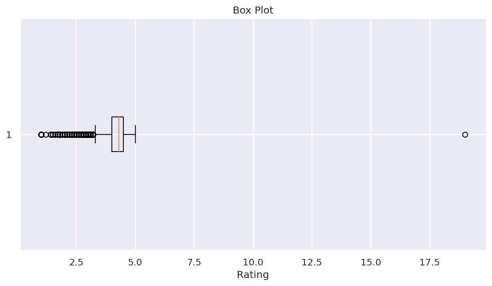

```python
# box plot will help to findout the outliers within Rating column
# Create a new figure object with a size of 7.5 x 4 inches
plt.rcParams["figure.figsize"] = [10, 5]

# Create a new figure and axis object
fig, ax = plt.subplots()

# Create the box plot
ax.boxplot(df1['Rating'],vert=False)


# Add a title and axis labels
ax.set_title('Box Plot')
ax.set_xlabel('Rating')

# Show the chart
plt.show()
```

```python
# To find out null values from Android Version column
df1.loc[df1['Android Ver'].isnull()]
```

|  | App | Category | Rating | Reviews | Size | Installs | Type | Price | Content Rating | Genres | Last Updated | Current Ver | Android Ver |
| --- | --- | --- | --- | --- | --- | --- | --- | --- | --- | --- | --- | --- | --- |
| 4453 | [substratum] Vacuum: P | PERSONALIZATION | 4.4 | 230 | 11M | 1,000+ | Paid | $1.49 | Everyone | Personalization | July 20, 2018 | 4.4 | NaN |
| 4490 | Pi Dark [substratum] | PERSONALIZATION | 4.5 | 189 | 2.1M | 10,000+ | Free | 0 | Everyone | Personalization | March 27, 2018 | 1.1 | NaN |
| 10472 | Life Made WI-Fi Touchscreen Photo Frame | 1.9 | 19.0 | 3.0M | 1,000+ | Free | 0 | Everyone | NaN | February 11, 2018 | 1.0.19 | 4.0 and up | NaN |

```python
# Drop third raw from NaN value as it contain rating as 19.0 which is obviously outlier
df1.drop([10472], inplace = True)
```

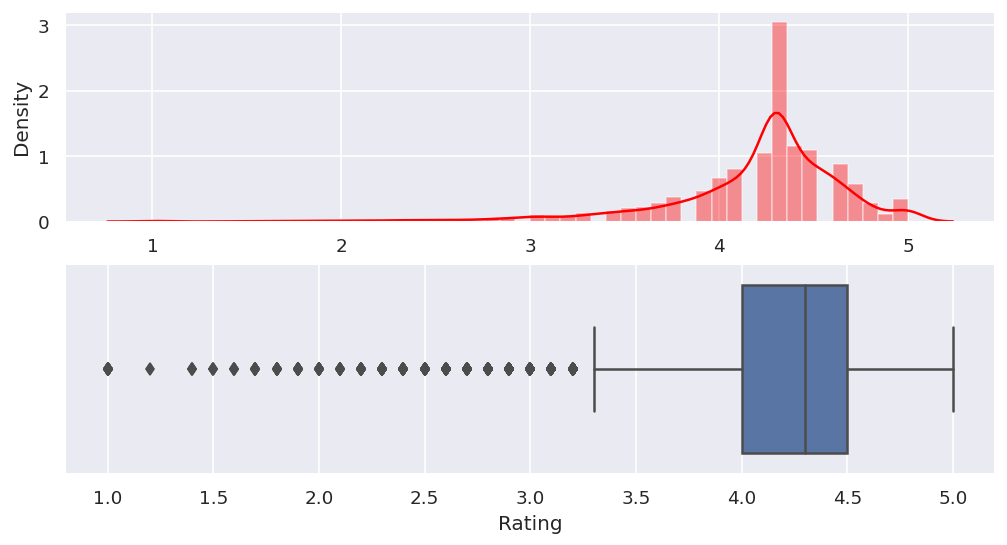

```python
# Using a boxplot to identify outliers and a distplot to visualise the rating distribution

fig, ax = plt.subplots(2,1)
sns.distplot(df1['Rating'],color='red',ax=ax[0])
sns.boxplot(x='Rating',data=df1, ax=ax[1])
plt.show()
```

```python
# To find out null values from Type column
df1.loc[df1['Type'].isnull()]
```

|  | App | Category | Rating | Reviews | Size | Installs | Type | Price | Content Rating | Genres | Last Updated | Current Ver | Android Ver |
| --- | --- | --- | --- | --- | --- | --- | --- | --- | --- | --- | --- | --- | --- |
| 9148 | Command & Conquer: Rivals | FAMILY | 4.3 | 0 | Varies with device | 0 | NaN | 0 | Everyone 10+ | Strategy | June 28, 2018 | Varies with device | Varies with device |

```python
# To drop null value from Type column
df1.drop([9148], inplace = True)
```

```python
# removing null values from Current vesion column by replacing with mode
df1['Current Ver'].fillna(df1['Current Ver'].mode()[0], inplace=True)
```

```python
#  to replace NaN value in Android ver to Varies with device
df1['Android Ver'].fillna('Varies with device', inplace=True)
```

```python
df1.info()
```

```
<class 'pandas.core.frame.DataFrame'>
Int64Index: 9658 entries, 0 to 10840
Data columns (total 13 columns):
 #   Column          Non-Null Count  Dtype
---  ------          --------------  -----
 0   App             9658 non-null   object
 1   Category        9658 non-null   object
 2   Rating          9658 non-null   float64
 3   Reviews         9658 non-null   object
 4   Size            9658 non-null   object
 5   Installs        9658 non-null   object
 6   Type            9658 non-null   object
 7   Price           9658 non-null   object
 8   Content Rating  9658 non-null   object
 9   Genres          9658 non-null   object
 10  Last Updated    9658 non-null   object
 11  Current Ver     9658 non-null   object
 12  Android Ver     9658 non-null   object
dtypes: float64(1), object(12)
memory usage: 1.0+ MB
```

```python
# Just to check whether there is null values present in dataframe
df1.isna().sum()
```

```
App               0
Category          0
Rating            0
Reviews           0
Size              0
Installs          0
Type              0
Price             0
Content Rating    0
Genres            0
Last Updated      0
Current Ver       0
Android Ver       0
dtype: int64
```